# CanvasXpress: SPLOM Chart

[figure not shown]

[figure not shown]

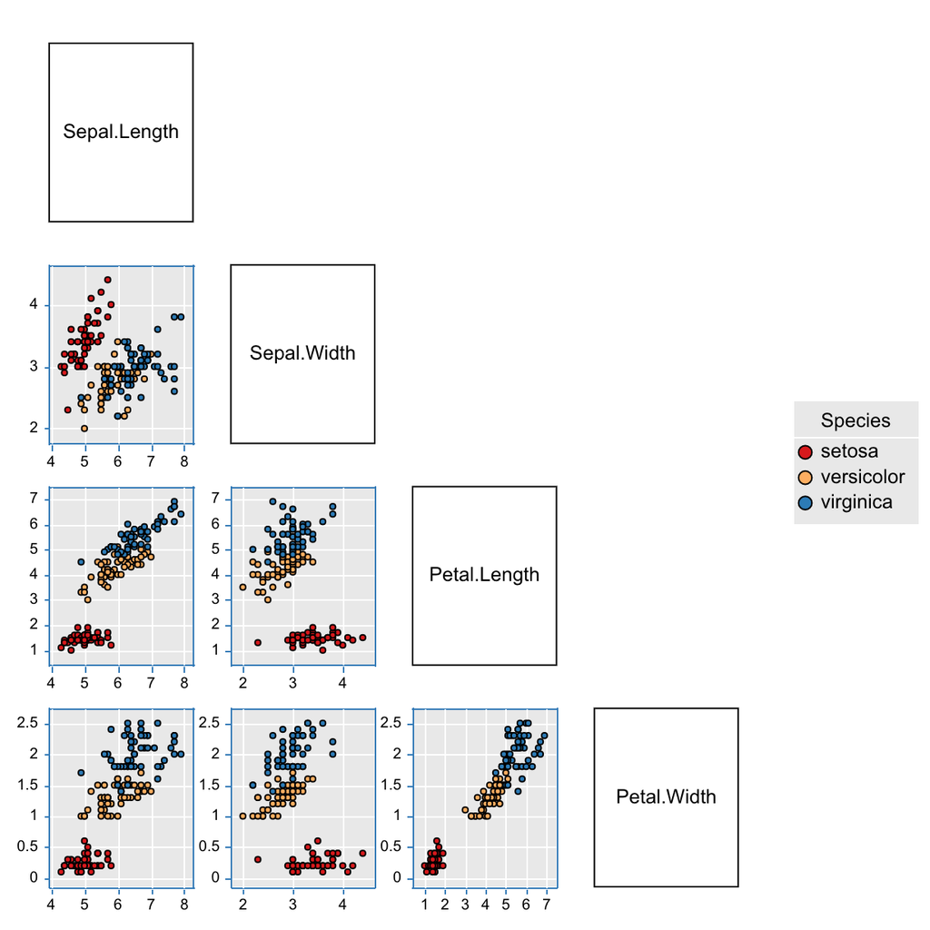

[figure not shown]

[figure not shown]

[figure not shown]

[figure not shown]

[figure not shown]

```r
library(canvasXpress)
y=read.table("https://www.canvasxpress.org/data/cX-irist-dat.txt", header=TRUE, sep="\t", quote="", row.names=1, fill=TRUE, check.names=FALSE, stringsAsFactors=FALSE)
z=read.table("https://www.canvasxpress.org/data/cX-irist-var.txt", header=TRUE, sep="\t", quote="", row.names=1, fill=TRUE, check.names=FALSE, stringsAsFactors=FALSE)
canvasXpress(
  data=y,
  varAnnot=z,
  broadcast=TRUE,
  colorBy="Species",
  graphType="Scatter2D",
  layoutAdjust=TRUE,
  scatterPlotMatrix=TRUE,
  scatterPlotMatrixType="lower",
  theme="CanvasXpress"
)
```

Show All

⇧